# Daily news - 14.12.2016

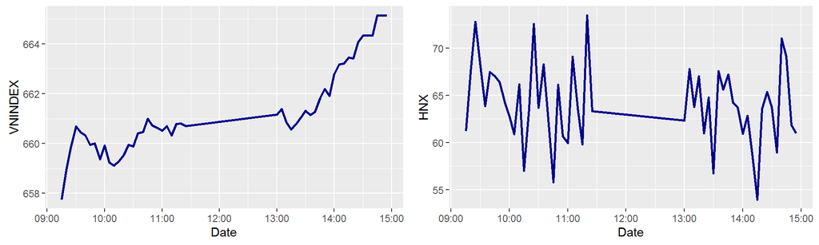

The market will likely incur cautious movement on a low liquidity ahead of the FED meeting. VnIndex may extend its rally but the market will still experience a divergence and is unlikely to gain across the board. Investors should not raise stock exposure to a high level.

### OUTPERFORM DGW: Moving up Value Chain in Distribution

Here are some key findings:

- we forecast annual decrease in Revenues (-5.6%), Gross profit (-7.2%) and Net Profit (-22.4%)
- these figures can be explained by increased sales expenses and drop in Nokia sales (from VND879m to 0)
- This negative news is already priced in VND 23,000/share.

We however see that: * DGW now manages the whole Values chain from Sales - Logistics to newly added Marketing and Own research & analysis with highest value added operations.

- Strategic retail market has about 6,000 sales point is 63 cities scattered across the whole Vietnam. This attracts other suppliers who want to propagate their products.
- DGW became an official distributor for FREETEL products which gained its popularity in Japan (brand #2 after Sony). Revenues from Mobile phones (excluding Nokia) doubled from 2015 to 2016.

**We therefore issue OUTPERFORM recommendation with target price VND 28,000**

[interactive chart not shown]

### Major Economic News

**European Central Bank (ECB) extends its asset purchase** program until the end of 2017 but cuts the size of the purchases. Specifically, in the meeting on December 8, ECBannounced it would extend its asset purchase program by at least a further nine months until the end of 2017 (longer than the six months that markets had been anticipating), but to reduce the monthly purchases from €80 billion to €60 billion from April onwards. Accordingly, ECB decided to keep its monetary stimulus, aiming to boost stubbornly weak inflation and sluggish growth in the Eurozone. This raised a conflict between ECB and FED monetary policy. The U.S. Federal Reserve (FED) will likely increase the interest rates next week. The U.S. monetary policy is forecast to be tightened and replaced by fiscal spending under President-elect Donald Trump. Due to the difference between FED and ECB monetary policy, the EUR/USD exchange rate tumbled over the past few months to 1,0627 currently (down nearly 8% from 1,1534 in early May) and would continue to fall in the coming time. This movement will support stocks having large outstanding loans in Euro.

**Oil prices tend to rally** for a second consecutive session ahead of the meeting between OPEC and non-OPEC members. Currently, at 3 p.m. as of Vietnam time, WTI and Brent crude prices respectively rose by 0.77% and 0.35% to US$51.23 a barrel and US$54.08 a barrel. Investors hopes the output cut agreement would be strengthened by producers outside OPEC. However, as the possibility of a 600,000 barrels/day cut remains skeptical, the rally of oil prices is unconvincing. Currently, Russia has said it will cut 300,000 barrels per day from a record of 11.23 million barrels per day in November. Oman has publicly stated it is willing to cut production by 5-10% while Azerbaijan has indicated it will lower supply. According to Reuters, among the 14 non-OPEC countries invited to attend Saturday’s meeting, only Azerbaijan, Kazakhstan, Oman, Mexico and Russia have accepted. China and the U.S. will not attend the meeting as they are oil importers and declining oil prices will boost the economic growth. If the 600,000 barrels/day cut deal is not reached by non- OPEC members, oil prices will stop rallying and fluctuate around US$50/barrel before any impacts.